# Scalable Bayesian Inference for Streaming Data

2 November 2016

## Streaming Data

- There are many sources of streaming data
  - Streaming video: Netflix, YouTube, Amazon Video etc
  - Social Media: Twitter, Facebook etc
  - Connected Devices, the internet of things
- Streaming data is large, typically hetergeneous and typically correlated in time
- Analysing this data online is desirable; reducing storage and computational costs and allowing decisions to be made more quickly

## Urban Observatory Air Quality Data

[interactive chart not shown]

## Urban Observatory Readings

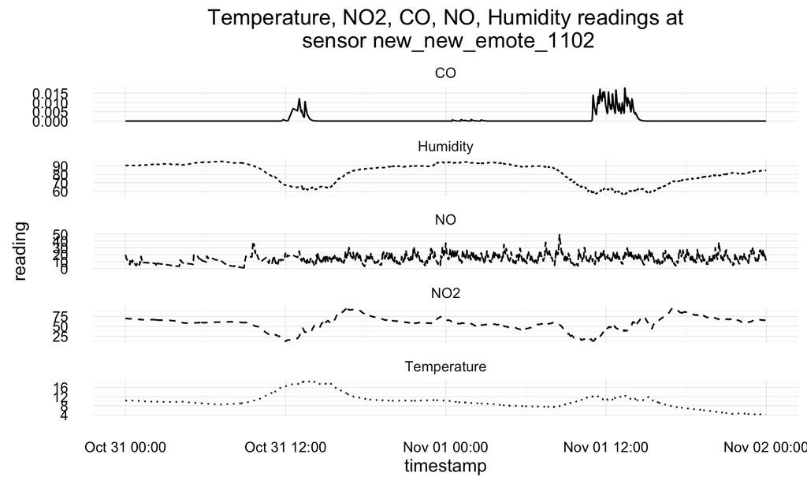

## Bayesian Parametric Inference

- Given data, \(y\), we want to fit a model with parameters \(\theta\)
- Bayes theorem allows us to do this

\[p(\theta | y) = \frac{p(\theta)p(y | \theta)}{p(y)} \]

- \(p(\theta | y)\) is the posterior distribution, \(p(\theta)\) is the prior distribution, \(p(y|\theta\)) the likelihood and \(p(y) = \int_\theta p(y | \theta) p(\theta) \textrm{d}\theta\)
- Once parameters have been determined, the parametric model can be used to answer questions about the process which generated the data, \(y\)

## Streaming Data

- Streaming data is observed as a chronological sequence of values, \(Y\), with an associated timestamp, \(t_i\)

\[ Y(t_{0:N}) = \{y(t_0), y(t_1), \dots , y(t_N) \} \]

- The Bayesian framework is natural for streaming time series data
- We want to forecast future observations: \(y(t_k), k > N\)
- We do this by fitting a parametric model which describes the process

## Regularly Observed Data

- Streaming data is often irregularly observed, consider first a completely observed discrete sensor for a lightbulb
- The lightbulb can be considered either on, or off, here is a regularly observed series of the lightbulb

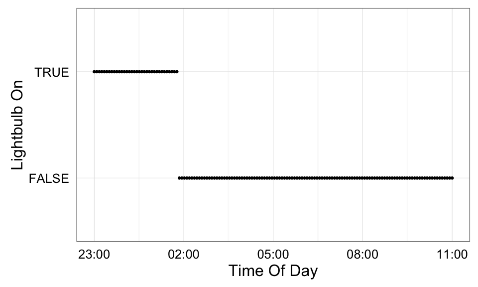

- The lightbulb reports its status every five minutes, leading to \(\frac{60}{5} \times 24 = 288\) observations each day

## Time to Event Data

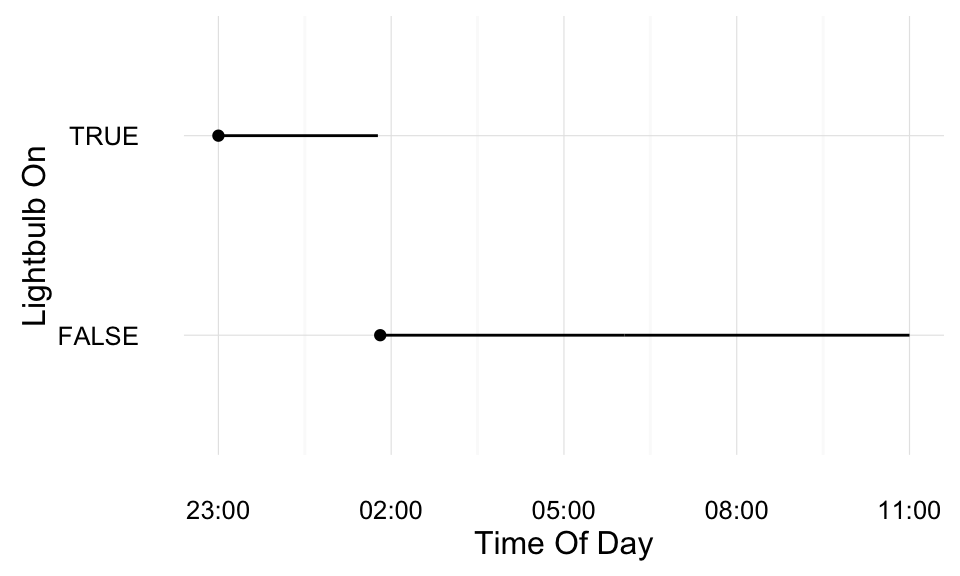

## Irregularly Observed Data

- Sometimes a continuous process can be observed at discrete irregular intervals
- This is typically the case with sensor data, sometimes sensors can go offline or change their sampling rate adaptively

## Modelling Irregularly Observed Data

### POMP Models

- Partially Observed Markov Process model

\[\begin{align*} y(t_i)|\eta(t_i) &\sim \pi(y(t_i) | \eta(t_i)), \\ \eta(t_i)|\textbf{x}(t_i) &= g(F_{t_i}^T \textbf{x}(t_i)), \\ \textbf{X}(t_i) | \textbf{x}(t_{i-1}) &\sim p(\textbf{x}(t_i) | \textbf{x}(t_{i-1})) \end{align*}\]

- The observation distribution \(\pi(.)\) is flexible
- The function \(g\) permits a deterministic non-linear transformation of the state space
- \(F_t\) is a time dependent vector representing a linear transformation
- The state space, \(\textbf{x}(t)\) is a continuous time Markov process

## POMP Model

### Representation of a POMP model as a directed acyclic graph (DAG)

[figure not shown]

## The State Space

### Diffusion Process Plot, Generalised Brownian Motion

\[\textrm{d}X(t) = \mu X(t) \textrm{d}t + \sigma \textrm{d}W(t)\]

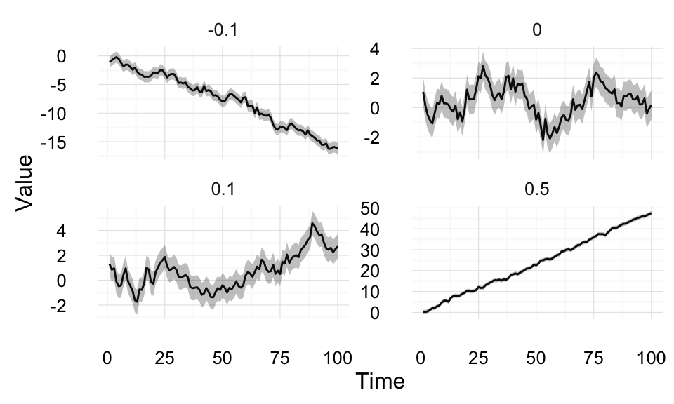

## The State Space

### Diffusion Process Plot, Ornstein-Uhlenbeck Process

\[\textrm{d}X(t) = \alpha (\theta - X(t)) \textrm{d}t + \sigma \textrm{d}W(t)\]

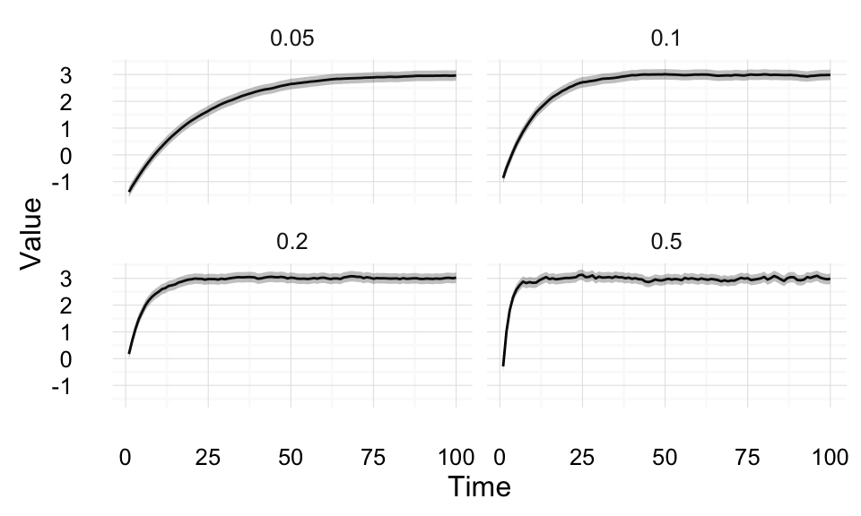

## Example POMP Model

### A Poisson Model

\[\begin{align*} N(t) &\sim \textrm{Poisson}(N(t) | \lambda(t)) \\ \lambda(t_i) &= \exp\{ x(t) \} \\ \textrm{d}X(t) &= \mu X(t)\textrm{d}t + \sigma \textrm{d}W(t) \end{align*}\]

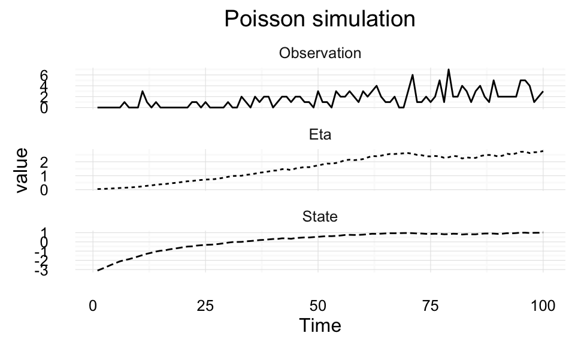

## Composing POMP models

### Modelling Complex Processes

- Define an associative binary composition operator for models
- The Left-hand observation model and linking function, \(g\) are chosen
- The Linear transformation vectors are concatenated: \(F^{(3)}_t = \begin{bmatrix} F^{(1)}_t \\ F^{(2)}_t \end{bmatrix}\)
- The latent state of each model advances according to its state evolution equation:

\[ \textbf{X}(t_i) | \textbf{x}(t_{i-1}) \sim \begin{pmatrix} p_1(\textbf{x}^{(1)}(t_i) | \textbf{x}^{(1)}(t_{i-1})) \\ p_2(\textbf{x}^{(2)}(t_i) | \textbf{x}^{(2)}(t_{i-1})) \end{pmatrix} \]

- The class of unparameterised models and the composition operator forms a semi group

## Composed POMP Example

### A Seasonal Time To Event Model

- Closely related to the Poisson Model, is the Log-Gaussian Cox-Process
- Consider an inhomogeneous Poisson process, with rate \(\lambda(t)\), then the total number of events in \((0,T]\) is:

\[N(t) \sim \textrm{Poisson}\left (\int_0^T \lambda(t) \textrm{d}s \right )\]

## Composed POMP Example

### A Seasonal Time To Event Model

- Denote \(\Lambda(t) = \int_0^t \lambda(s) \textrm{d}s\) and calculate the probability of observing at least one event:

\[\begin{align*} P(N(t) > 0) &= 1 - p(N(t) = 0) \\ &= 1 - \frac{\Lambda(t)^0 e^{-\Lambda(t)}}{0!} \\ & = 1 - \exp \left \{ -\Lambda(t) \right \} \end{align*}\]

- This is equivalent to the CDF of the LGCP, the PDF is given by:

\[f(t) = \frac{\textrm{d}}{\textrm{d}t}F(t) = \lambda(t) \exp \left \{-\Lambda(t) \right \}\]

## Composed POMP Example

### A Seasonal Time To Event Model

- The LGCP model, with a generalised brownian motion state space is then:

\[\begin{align*} p(t|\lambda(t)) &= \lambda(t) \exp \left \{-\Lambda(t) \right \} \\ \begin{pmatrix} \lambda(t) \\ \textrm{d}\Lambda(t) \end{pmatrix} &=\begin{pmatrix} \exp \{x(t)\} \\ \lambda(t)\textrm{d}t \end{pmatrix}\\ \textrm{d}X(t) &= \mu X(t) \textrm{d}t + \sigma \textrm{d}W(t) \end{align*}\]

- We can model time to event data, such as the lightbulb series

## Composed POMP Example

### A Seasonal Time To Event Model

- Define a seasonal model, with an Ornstein-Uhlenbeck state space

\[\begin{align*} y(t) &\sim \mathcal{N}(y(t) | \mu(t), \sigma) \\ \mu(t) &= F_t^T \textbf{x}(t) \\ \textrm{d}\textbf{X}(t) &= \alpha(\theta - \textbf{X}(t)) \textrm{d}t + \Sigma \textrm{d}W(t) \end{align*}\]

- \(F_t^T\) is a time dependent vector of fourier components representing seasonality:

\[F_t = \begin{pmatrix} \cos(\omega t) \\ \sin(\omega t) \\ \cos(2\omega t) \\ \sin(2\omega t) \\ \cos(3\omega t) \\ \sin(3\omega t) \end{pmatrix}\]

## Composed POMP Example

### A Seasonal Time To Event Model

\[\begin{align*} t &\sim \pi(t | \lambda(t), \Lambda(t)) \\ \begin{pmatrix}\lambda(t_i) \\ \Lambda(t_i) \end{pmatrix} &= \begin{pmatrix} \exp\{ F_t^T x(t) \} \\ \lambda(t_i) \textrm{d}t \end{pmatrix}\\ \textbf{X}(t_i)|\textbf{x}(t_{i-1}) &\sim \begin{pmatrix} p_1(\textbf{x}^{(1)}(t_i) | \textbf{x}^{(1)}(t_{i-1})) \\ p_2(\textbf{x}^{(2)}(t_i) | \textbf{x}^{(2)}(t_{i-1})) \end{pmatrix} \end{align*}\]

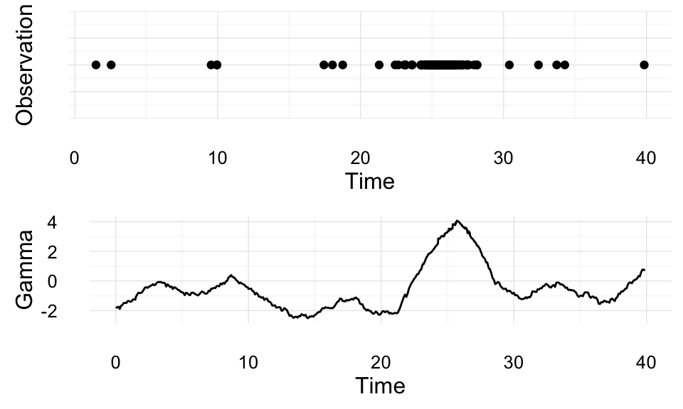

## Programming with Streams

## Stream

### An infinite list

- `Stream`s can be thought of as an infinite list
- A Stream is pair, with the left hand value being the first element of the stream and the right hand value a thunk (a function with no arguments)
- Define a (infinite) stream of natural numbers using `from`

```scala
scala> val naturalNumbers = Stream.from(1)
```

`Stream(1, ?)`

## Akka Streams

- Akka Streams: A Scala library for stream processing
- Akka streams have three main abstractions:
- A `Source` is a definition of a stream, it can be a "pure" stream, or a database or webservice call
- A `Flow` is a processing stage, which can be used to transform a `Source` to another `Source`
- A `Sink` defines what happens at the end of the stream, usually an effect such as writing to a file

## Higher Order Functions

### Operations on Streams

- `fold` can be used (with a seed) to reduce a `Stream` by recursively applying a binary operation

```scala
scala> Stream.from(1).
take(10).
fold(0)(_ + _)
```

`55`

- `fold` will reduce a stream from the left, `((1 + 2) + 3) + 4`
- `reduce` is equivalent to `fold` for associative operations and does not guarantee order of operations

## Higher Order Functions

### Operations on Streams

- `scan` can be used to accumulate a running sum:

```scala
scala> Stream.from(1).
take(10).
scan(0)(_ + _)
```

`0, 1, 3, 6, 10, 15, 21, 28, 36, 45, 55`

## POMP models as a Stream

- The latent state is a Markov process, which means future observations only depend on the current observation

\[p(x(t_n) | x(t_{n-1}), \dots x(t_0)) = p(x(t_n) | x(t_{n-1}))\]

- In order to simulate the Markov Process, we can use the dual of `fold`, `unfold`, to simulate a random walk:

\[x(t) = x(t-1) + w(t), \quad w(t) \sim \mathcal{N}(0, W)\]

```scala
val x0 = Gaussian(0.0, 1.0).draw

Source.unfold(x0)(a => Some((Gaussian(a, sigma).draw, a)))
```

## Bayesian Inference with Streams

### The Bootstrap Particle Filter

- In general, POMP models require simulation based filtering (such as the bootstrap filter (Gordon, Salmond, and Smith 1993)) to determine the behaviour of the latent state
- Let's describe a bootstrap filter for this Poisson model:

\[\begin{align*} y(t_i) &\sim \textrm{Poisson}(y(t_i) | x(t_i)) \\ \lambda(t_i) &= \exp \{ x(t_i) \} \\ dX(t_i) &= \mu X(t) \textrm{d}t + \sigma \textrm{d}W(t) \end{align*}\]

- Initialize: Sample \(N\) particles from the state prior distribution, \(x^{(i)}(t_0) \sim p(x(t_0))\), set the weights to \(1/N\), \(w^{(i)}(t_0) = 1/N\):

```scala
val n = 1000 // number of particles
val (x, w) = (Gaussian(0.0, 1.0).sample(n), Seq.fill(n)(1/n))
```

## Bayesian Inference with Streams

### The Bootstrap Particle Filter

- Advance the particles to the time of the next observation, using the state transition model \(x^{(i)}(t_k) \sim p(x^{(i)}(t_k) | x^{(i)}(t_{k-1}))\)

```scala
def stepState(mu: Double, sigma: Double)
  (x: State, dt: TimeIncrement): State = {
    Gaussian(x + mu * dt, sigma * sigma * dt).draw
}
val x1 = x map (stepState(_, dt))
```

- Calculate the likelihood (weight) of each particle, given the observation at time \(t_k\), \(w^{(i)}(t_k) = \textrm{Poisson}(y(t_k) | \lambda(t_k)^{(i)}(t_k))\)

```scala
val weights = x1 map (x => Poisson(exp(x)).pdf(observation))
```

## Bayesian Inference with Streams

### The Bootstrap Particle Filter

- Resample the particles according to the weights, ie. select particle \(j\) with probability \(w^{(j)}(t_k)\)

```scala
def resample(w: Seq[LogLikelihood], x: Seq[State]) = {
  Multinomial(w).sample(x.size) map (i => x(i))
}
```

- Store the approximate sample from the filtering distribution, \(\hat{p}(x(t_k) | y(t_k))\)
- Advance to the time of the next observation, and repeat without the intialization step

## Bayesian Inference with Streams

### The Bootstrap Particle Filter

- Here's the full implementation of a single step of the bootstrap particle filter for the simple Poisson model

```scala
case class Data(time: Datetime, observation: Double)
case class FilterState(t0: Datetime, state: Seq[State])

def stepFilter(s: FilterState, d: Data): FilterState = {
  val dt = d.time - s.t0
  val state = s.state map (x => stepState(x, dt))
  val w = state map (x => Poisson(exp(x), v).logPdf(d.observation))

  FilterState(d.time, resample(w, state))
}
```

## Bayesian Inference With Streams

### The Bootstrap Particle Filter

- In order to perform the bootstrap particle filter, we need to know the time of the previous observation and the previous particle cloud
- The the filter can by ran using an akka `Flow` and the `scan` operation, the initial state `init` contains the particle cloud and the time at the start of the application of the filter

```scala
def filter(init: FilterState) =
  Flow[Data].scan(init)(stepFilter)

dataStream.
  via(filter(init)).
  runWith(Sink.foreach(println))
```

- The particle filter will be applied to the data stream one element at a time, a `Source` and print the result to the console as each datapoint is processed

## Bayesian Inference With Streams

### Parallel Particle Filters

- In order to account for the uncertainty of the parameter estimates, we can sample from the parameter posterior \(p(\theta | y(t_{1:N}))\) and run multiple particle filters
- Running multiple particle filters (in parallel) is trivial, assume `variance` is the posterior distribution of the variance:

```scala
Source(variance.sample(4).toList).
  mapAsync(2){ v =>
    Source(sims).
      take(100).
      via(filter(v, init)).
      runWith(Sink.ignore)
  }
```

- The full implementation of this can be found in the associated github repo git.io/scalable

## Illustration of Bootstrap Particle Filter

- The solid line represents the simulated state, the points represent the particle cloud with the opacity representing each particles likelihood

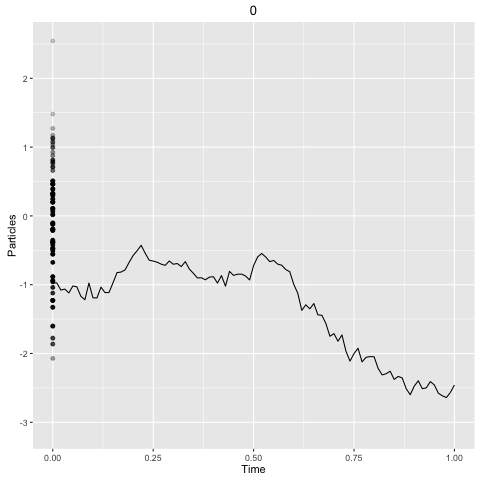

## Parameter Inference for POMP models

- **Offline Parameter Inference**:
  - MCMC algorithms: Particle Marginal Metropolis Hastings (Andrieu and Roberts 2009)
- **Online Parameter Inference**:
  - Liu and West (Liu and West 2001)
  - Storvik Filter (Storvik 2002)
  - Particle Learning (Carvalho et al. 2010)

## Conclusion

- Bayesian Inference for irregularly observed time series
  - Improves accuracy of inference
  - Reduces computational cost
  - Regularly observed data is simply a special case

**Further Reading**

- I have written a Scala library which implements composable POMP models and inference methods
- Look at the code: git.io/statespace
- Read the paper: [arXiv:1609.00635](https://arxiv.org/abs/1609.00635)

## References

Andrieu, Christophe, and Gareth O. Roberts. 2009. “The pseudo-marginal approach for efficient Monte Carlo computations.” *Annals of Statistics* 37 (2): 697–725. doi:10.1214/07-AOS574.

Carvalho, Carlos M., Michael S. Johannes, Hedibert F. Lopes, and Nicholas G. Polson. 2010. “Particle Learning and Smoothing.” *Statistical Science* 25 (1): 88–106. doi:10.1214/10-STS325.

Gordon, N.J., D.J. Salmond, and a.F.M. Smith. 1993. “Novel approach to nonlinear/non-Gaussian Bayesian state estimation.” *IEE Proceedings F Radar and Signal Processing* 140 (2): 107. doi:10.1049/ip-f-2.1993.0015.

Liu, Jane, and Mike West. 2001. “Combined Parameter and State Estimation in Simulation-Based Filtering.” Springer, 197–223.

Storvik, Geir. 2002. “Particle filters for state-space models with the presence of unknown static parameters.” *IEEE Transactions on Signal Processing* 50 (2): 281–89. doi:10.1109/78.978383.